# Player Impact and Efficiency Analysis: 2024 NWSL Season

Zelda Natty

2026-04-07

Introduction This project analyzes 2024 NWSL player statistics to evaluate performance efficiency and identify key predictors of offensive success. The dataset includes 344 players across 40 performance variables. Missing values in games_started were interpreted as substitute appearances and replaced with 0. Players with fewer than 300 minutes were removed to prevent distortion in per-90 metrics.

This project analyzes 2024 NWSL player statistics to evaluate performance efficiency and identify key predictors of offensive success. The dataset includes 344 players across 40 performance variables. Missing values in games_started were interpreted as substitute appearances and replaced with 0. Players with fewer than 300 minutes were removed to prevent distortion in per-90 metrics.

1. Goals by Positions

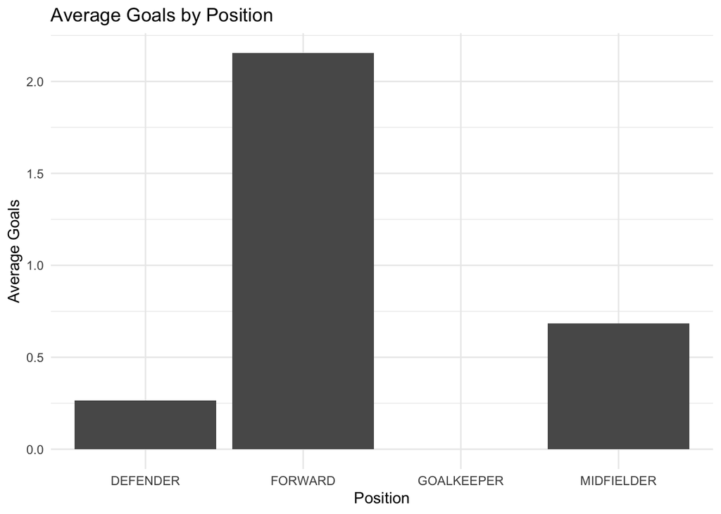

```r
df %>%
  group_by(position) %>%
  summarise(avg_goals = mean (goals, na.rm = TRUE)) %>%
  ggplot(aes(x = position, y = avg_goals)) +
  geom_col() +
  theme_minimal() +
  labs (
    title = "Average Goals by Position",
    x = "Position",
    y = "Average Goals"
  )
```

Interpretation: Forwards demonstrate the highest average goal output, as expected. Midfielders contribute moderately, while defenders show minimal scoring output. This confirms positional role differentiation within offensive production.

2. Contribution per 90 Minutes by Position

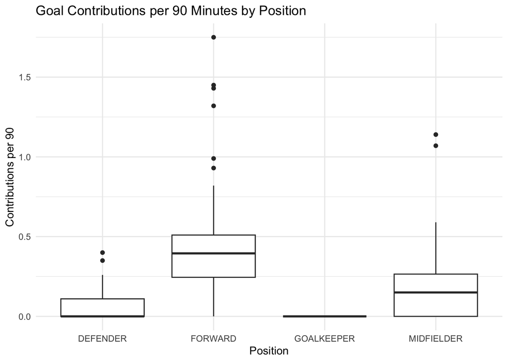

```r
ggplot(df, aes(x = position, y = contribution_per_90)) +
  geom_boxplot() +
  theme_minimal() +
  labs(
    title = "Goal Contributions per 90 Minutes by Position",
    x = "Position",
    y = "Contributions per 90"
  )
```

Interpretation: While forwards lead in median contribution, there is substantial variability within the position. Some midfielders exhibit comparable efficiency, indicating creative playmakers significantly influence offensive output.

3. Minutes Played vs Goals

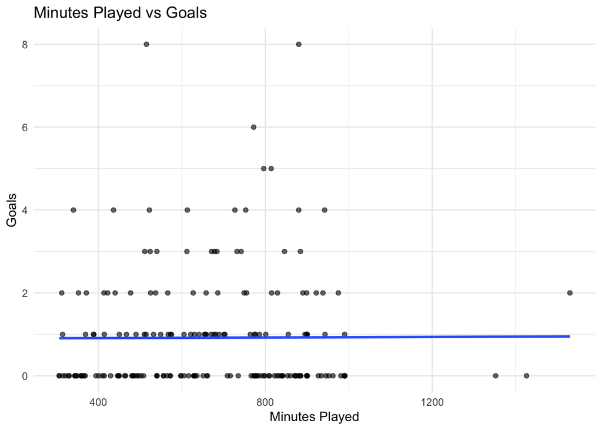

```r
ggplot(df, aes(x = minutes_played, y = goals)) +
  geom_point(alpha = 0.6) +
  geom_smooth(method = "lm", se = FALSE) +
  theme_minimal() +
  labs(
    title = "Minutes Played vs Goals",
    x = "Minutes Played",
    y = "Goals"
  )
```

4. Shot Volume vs Goal Conversion Rate

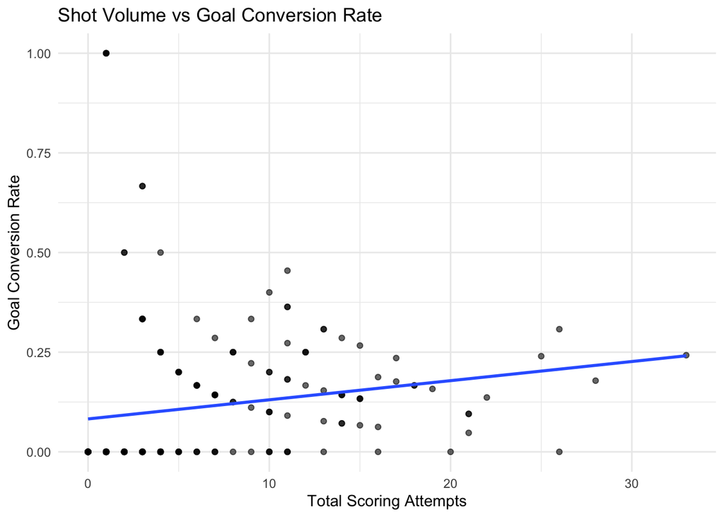

```r
ggplot(df, aes(x = total_scoring_attempts, y = goal_conversion_rate)) +
  geom_point(alpha = 0.6) +
  geom_smooth(method = "lm", se = FALSE) +
  theme_minimal() +
  labs(
    title = "Shot Volume vs Goal Conversion Rate",
    x = "Total Scoring Attempts",
    y = "Goal Conversion Rate"
  )
```

Interpretation: Players with higher shot volume do not always demonstrate higher conversion efficiency. This suggests that shot quality and positioning may be stronger indicators of elite finishing than volume alone.

5. Player Impact Score

```r
# Standardize Key Performance Metrics
df <- df %>%
  mutate(
    z_goals90 = scale(goals_avg_over_90_mins),
    z_assists90 = scale(assists_avg_over_90_mins),
    z_conversion = scale(goal_conversion_rate)
  )

# Create Player Impact Score
df <- df %>%
  mutate(
    player_impact_score =
      (0.5 * z_goals90) +
      (0.3 * z_assists90) +
      (0.2 * z_conversion)
  )
```

6. View Top Players

```r
df %>%
  arrange(desc(player_impact_score)) %>%
  select(player_name, team, player_impact_score) %>%
  head(10)
```

```
## # A tibble: 10 × 3
##    player_name        team                 player_impact_score[,1]
##    <chr>              <chr>                                  <dbl>
##  1 Barbra Banda       Orlando Pride                           3.78
##  2 Bia Zaneratto      Kansas City Current                     3.01
##  3 Sophia Smith       Portland Thorns                         2.94
##  4 Ella Stevens       NJ/NY Gotham FC                         2.85
##  5 Croix Bethune      Washington Spirit                       2.32
##  6 Vanessa DiBernardo Kansas City Current                     2.10
##  7 Temwa Chawinga     Kansas City Current                     1.86
##  8 Ouleymata Sarr     Washington Spirit                       1.80
##  9 Claire Emslie      Angel City FC                           1.73
## 10 Uchenna Kanu       Racing Louisville FC                    1.44
```

Goals are weighted at 50% due to their direct contribution to match outcomes. Assists were weighted at 30% to reflect play making value, while goal conversion efficiency was weighted at 20% to reward finishing quality.

7. Visualizations

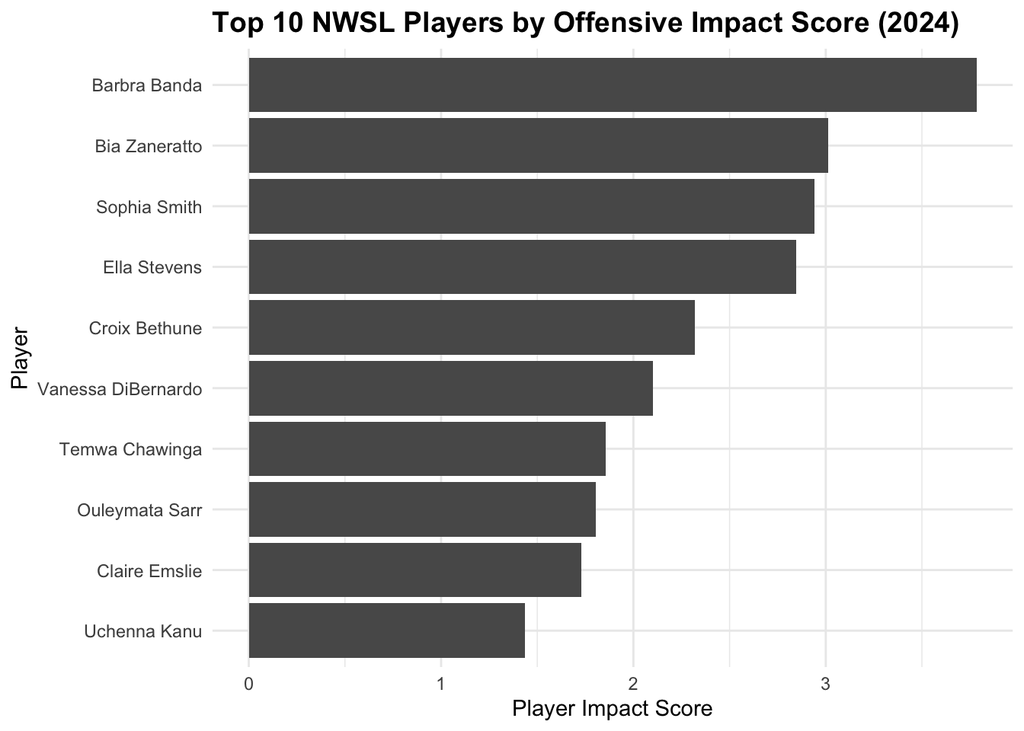

```r
top_players <- df %>%
  arrange(desc(player_impact_score)) %>%
  slice(1:10)

ggplot(top_players,
       aes(x = reorder(player_name, player_impact_score),
           y = player_impact_score)) +
  geom_col() +
  coord_flip() +
  labs(
    title = "Top 10 NWSL Players by Offensive Impact Score (2024)",
    x = "Player",
    y = "Player Impact Score"
  ) +
  theme_minimal() +
  theme (
    plot.title = element_text(size = 14, face = "bold")
  )
```

The visualization highlights the top 10 players based on the custom Player Impact Score. Players ranked highest demonstrate strong goal production combined with efficiency and assist contribution. This metirc provides a more comprehensive evaluation than goals alone.

8. Predictive Model

```r
model <- lm(goals ~ total_scoring_attempts +
              on_target_scoring_attempts +
              accurate_shooting_percentage +
              minutes_played,
            data = df)

summary(model)
```

```
##
## Call:
## lm(formula = goals ~ total_scoring_attempts + on_target_scoring_attempts +
##     accurate_shooting_percentage + minutes_played, data = df)
##
## Residuals:
##      Min       1Q   Median       3Q      Max
## -2.46745 -0.43906 -0.02319  0.26747  2.83022
##
## Coefficients:
##                                Estimate Std. Error t value Pr(>|t|)
## (Intercept)                   0.2263967  0.2216954   1.021    0.308
## total_scoring_attempts       -0.0149737  0.0253785  -0.590    0.556
## on_target_scoring_attempts    0.3258520  0.0451426   7.218 1.16e-11 ***
## accurate_shooting_percentage -0.0016494  0.0024034  -0.686    0.493
## minutes_played               -0.0002765  0.0002825  -0.979    0.329
## ---
## Signif. codes:  0 '***' 0.001 '**' 0.01 '*' 0.05 '.' 0.1 ' ' 1
##
## Residual standard error: 0.8504 on 194 degrees of freedom
## Multiple R-squared:  0.6533, Adjusted R-squared:  0.6462
## F-statistic: 91.39 on 4 and 194 DF,  p-value: < 2.2e-16
```